# Comparison of the GOF procedures when the claim sizes differ

Pierre-O Goffard

This notebooks presents the results of a Monte Carlo experience to compare the performance of the GOF test. We are testing three aggregated claim amounts model:

- Poisson - exponential
- Poisson - gamma
- Poisson - inverse Gaussian

We compare the CDF based goodness-of-fiot procedures to the Laplace transform based one. When using the SE distance, beta belongs to $\{10^{-3}, 10^{-2}\}$, while when the ODE distance is used then $\beta \in\{10^{-1}, 1\}$. The inference technique is always *partial-MME*.

[output not shown]

Test 1: We test samples coming from a $Poison(\lambda = 1)-gamma(r,\theta = 1)$ model with $r= 0.2,0.4,\ldots,2.$

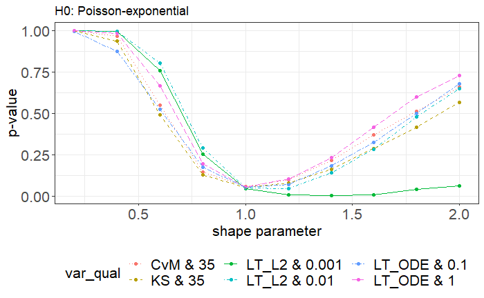

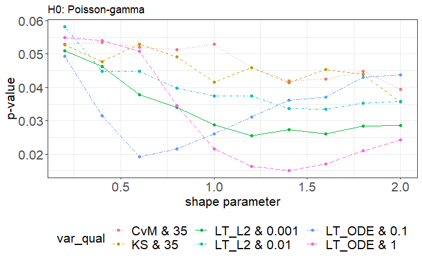

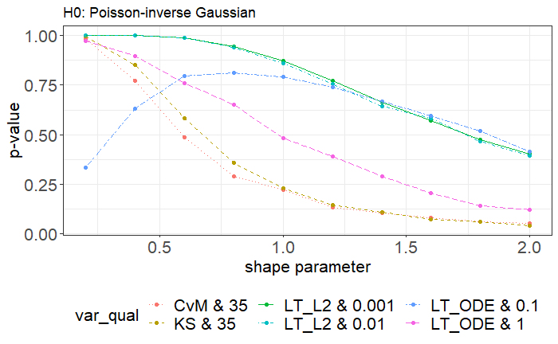

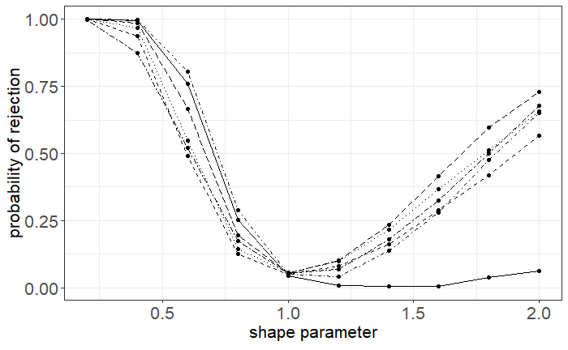

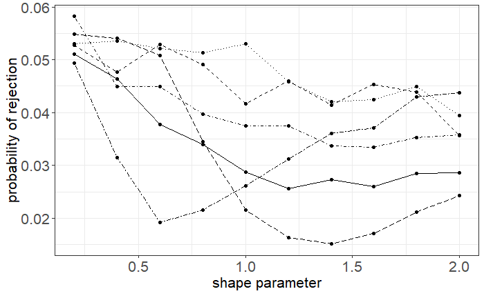

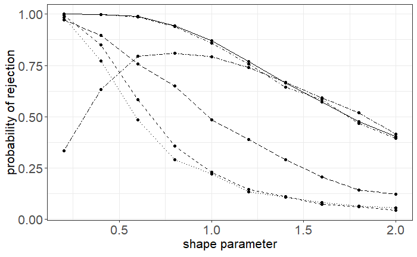

Test 2: We test samples coming from a $Poisson(\lambda = 1) - inverse Gaussian(\mu,\phi=1)$ model with $\mu = 0.2,0.4, \ldots, 2$

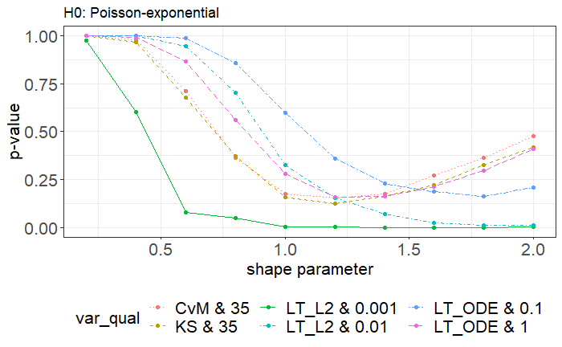

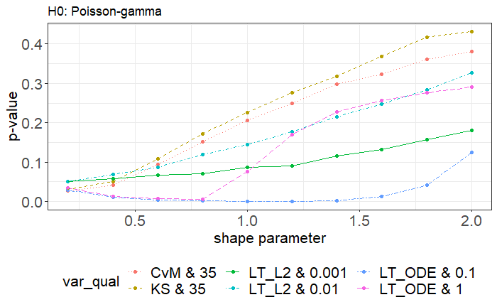

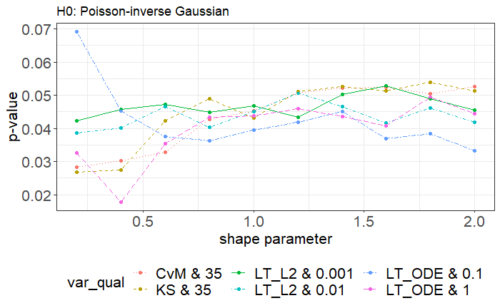

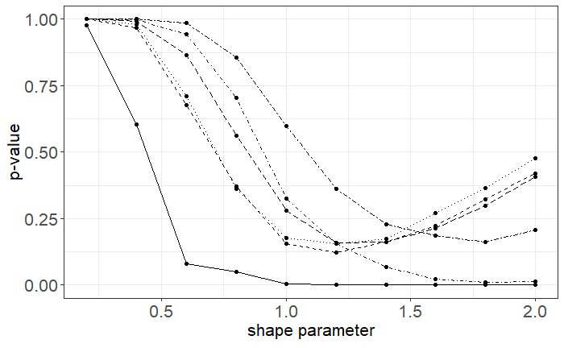

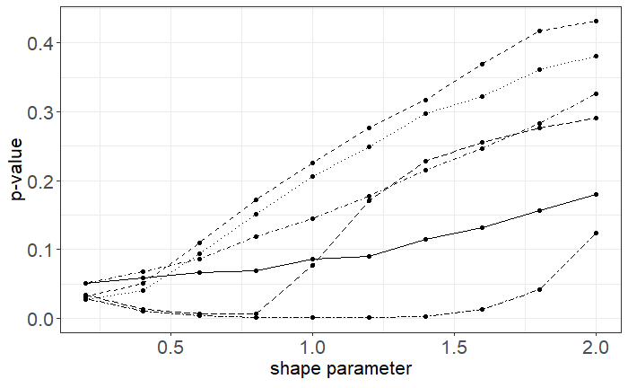

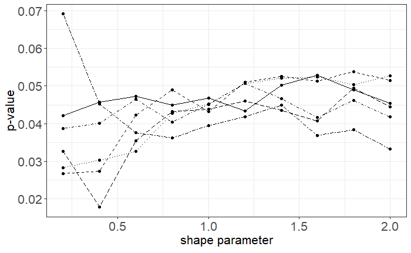

Test 3: We test samples from a $Poisson(\lambda = 1)-Weibull(\alpha, \beta = 1)$ model with $\alpha = 0.2, 0.4,\ldots,2$.

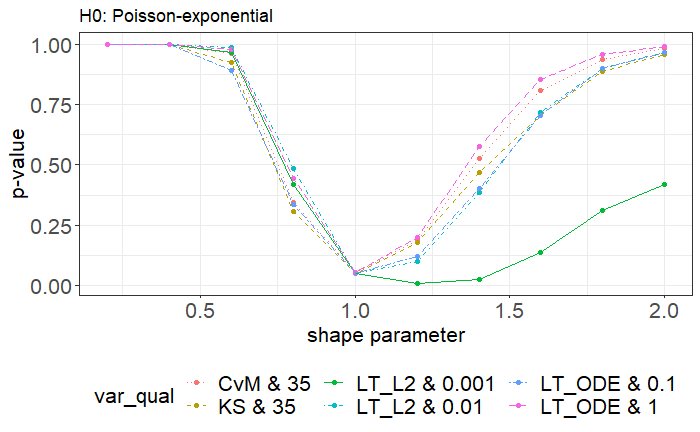

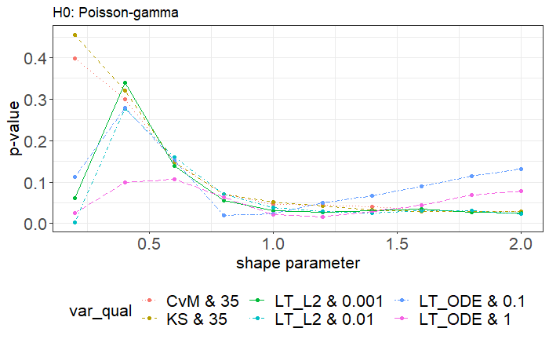

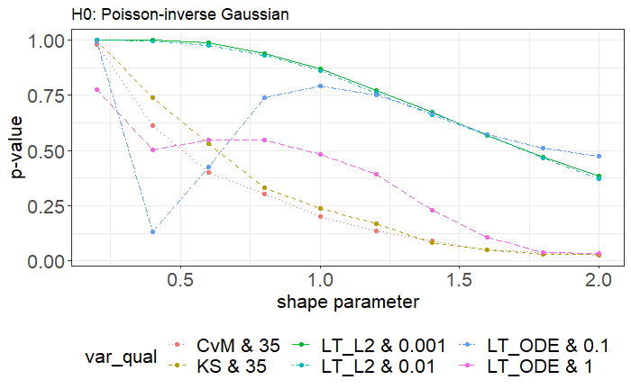

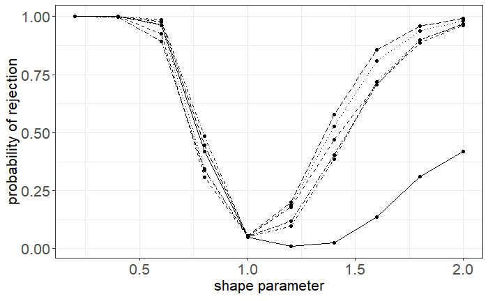

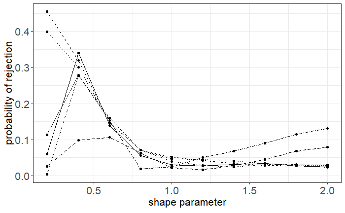

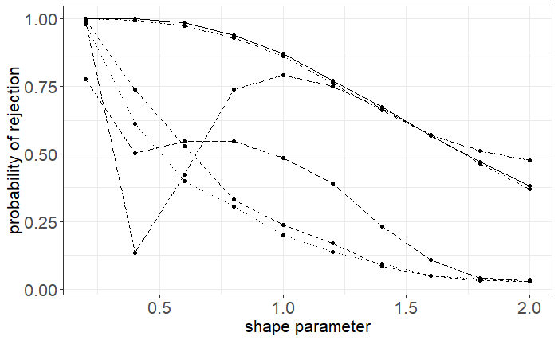

Test 4: We test samples from a $Poisson(\lambda = 1)-lognormal(\mu = 0,\sigma)$ model with $\sigma = 0.2,0.4,\ldots, 2.$

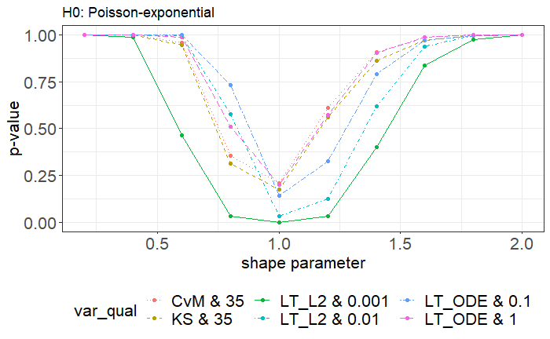

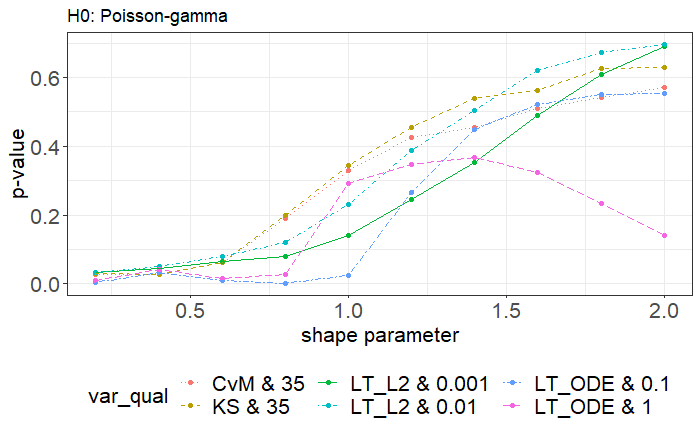

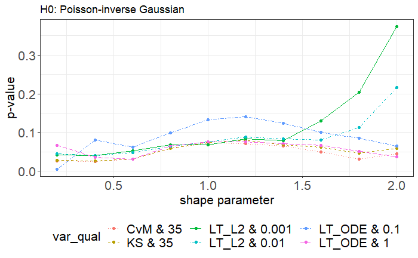

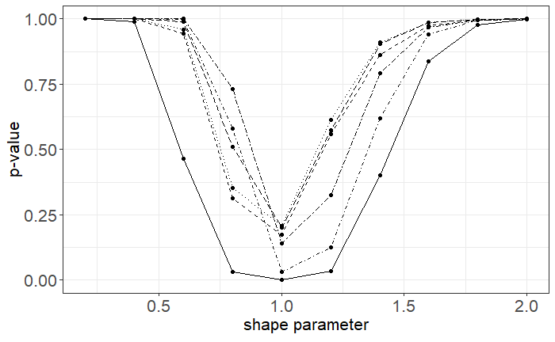

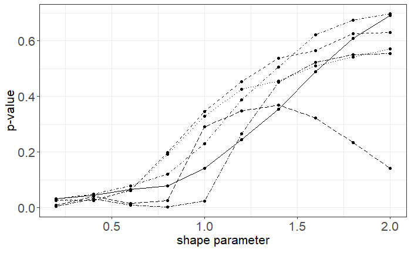

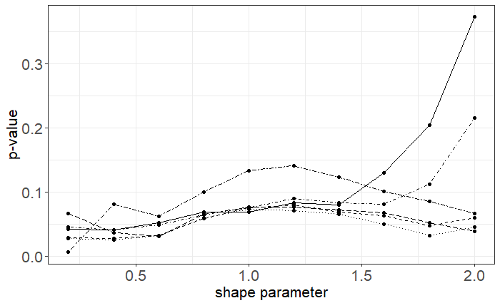